# Análisis exploratorio de datos en R

Docente: Felipe Calvo Cepeda - fcalvoc@unal.edu.co | Universidad Nacional de Colombia Docente invitada: Sandra Milena Munevar Meneses - UMNG-COLMEX

## Propósito de esta práctica

El análisis exploratorio de datos (EDA) busca conocer la estructura, distribución, calidad y relaciones posibles de una base antes de ajustar modelos. Explorar no significa probar una hipótesis definitiva: sirve para formular mejores preguntas y detectar problemas.

## Introducción

¿Qué aprenderemos?

- Cálculo de estadísticas descriptivas univariadas y multivariadas
- Método summary()
- Otros métodos de resumen
- Gráficas básicas univariadas y bivariadas
- Uso del paquete esquisse para crear gráficos en ggplot2

## Instalación de paquetes de EDA

```r
# Paquetes para hacer resúmenes de conjuntos de datos
# install.packages("summarytools")
# install.packages("skimr")

# Paquete para estimar la moda de un vector univariado
# install.packages("modeest")

# Paquete para hacer diversas gráficas
# install.packages("ggpubr")
```

## Importar paquetes y datos

```r
## Cargamos librerías
library("tidyverse")
library("skimr")
library("summarytools")
library("modeest")
library("ggpubr")

## Lectura
library("readxl")
read_xlsx(
  path = "data/Puntaje-Crediticio.xlsx",
  sheet= "DB"
) -> data_raw

## Revisar la estructura de los datos
str(data_raw)

## Transformamos el ID como una variable tipo char
data_raw$ID <- as.character(data_raw$ID)

## Convertimos variables respectivas a factores
factores <- c("Gender", "Has a car", "Has a property", "Employment status",
              "Education level", "Marital status", "Dwelling", "Has a mobile phone", "Has a work phone",
              "Has a phone", "Has an email", "Job title", "Is high risk")
data_raw %>% mutate_at(factores,factor) -> data

## Revisamos que la estructura de los datos esté ajustada
glimpse(data)

## Advertencia:
## Una vez la estructura está ajustada hay que hacer limpieza de datos
## Vamos a seguir el procesamiento con fines pedagógicos
```

[output not shown]

## Estadísticos descriptivos frecuentes

```r
# Univariados
mean() # para la media
median() #para la mediana
modeest::mfv() # para la moda
var() # para la varianza
sd() # para la desviación estándar
max() # para el máximo
min() # para el mínimo
quantile() # para los cuartiles
IQR() # para el rango intercuartílico
# Multivariados
cov() # para la covarianza
cor() # para la correlación
table() # para tablas de contingencia - también sirve en una variable
```

### Ejemplo: estadísticos descriptivos para la variable income (cuantitativa)

```r
mean(data$Income)
```

```
## [1] 185867.2
```

```r
median(data$Income)
```

```
## [1] 157500
```

```r
var(data$Income)
```

```
## [1] 10670152781
```

```r
sd(data$Income)
```

```
## [1] 103296.4
```

```r
max(data$Income)
```

```
## [1] 1575000
```

```r
min(data$Income)
```

```
## [1] 27000
```

```r
quantile(data$Income)
```

```
##      0%     25%     50%     75%    100%
##   27000  117000  157500  225000 1575000
```

```r
IQR(data$Income)
```

```
## [1] 108000
```

```r
# Moda
mfv(data$`Education level`)
```

```
## [1] Secondary / secondary special
## 5 Levels: Academic degree Higher education ... Secondary / secondary special
```

```r
# Frecuencias absolutas (Conteos)
table(data$`Education level`)
```

```
##
##               Academic degree              Higher education
##                             7                          1954
##             Incomplete higher               Lower secondary
##                           281                            76
## Secondary / secondary special
##                          4974
```

```r
# Frecuencias relativas (Proporciones)
prop.table(table(data$`Education level`))
```

```
##
##               Academic degree              Higher education
##                  0.0009599561                  0.2679648930
##             Incomplete higher               Lower secondary
##                  0.0385353812                  0.0104223807
## Secondary / secondary special
##                  0.6821173889
```

## Un método útil integrado en R: summary()

```r
## Resumen para una sola variable
summary(data$Income)
```

```
##    Min. 1st Qu.  Median    Mean 3rd Qu.    Max.
##   27000  117000  157500  185867  225000 1575000
```

```r
## Resumen para todo el conjunto de datos
summary(data)
```

```
##       ID            Gender   Has a car Has a property Children count
##  Length:7292        F:4881   0:4486    0:2343         Min.   : 0.0000
##  Class :character   M:2411   1:2806    1:4949         1st Qu.: 0.0000
##  Mode  :character                                     Median : 0.0000
##                                                       Mean   : 0.4284
##                                                       3rd Qu.: 1.0000
##                                                       Max.   :14.0000
##
##      Income                   Employment status
##  Min.   :  27000   Commercial associate:1689
##  1st Qu.: 117000   Pensioner           :1232
##  Median : 157500   State servant       : 604
##  Mean   : 185867   Student             :   4
##  3rd Qu.: 225000   Working             :3763
##  Max.   :1575000
##
##                       Education level              Marital status
##  Academic degree              :   7   Civil marriage      : 633
##  Higher education             :1954   Married             :5004
##  Incomplete higher            : 281   Separated           : 391
##  Lower secondary              :  76   Single / not married: 965
##  Secondary / secondary special:4974   Widow               : 299
##
##
##                 Dwelling    Has a mobile phone Has a work phone Has a phone
##  Co-op apartment    :  41   1:7292             0:5612           0:5147
##  House / apartment  :6489                      1:1680           1:2145
##  Municipal apartment: 216
##  Office apartment   :  54
##  Rented apartment   : 122
##  With parents       : 370
##
##  Has an email       Job title    Family member count  Account age
##  0:6654       Laborers   :1207   Min.   : 1.000      Min.   : 0.00
##  1: 638       Core staff : 725   1st Qu.: 2.000      1st Qu.:12.00
##               Sales staff: 712   Median : 2.000      Median :24.00
##               Managers   : 590   Mean   : 2.202      Mean   :26.27
##               Drivers    : 416   3rd Qu.: 3.000      3rd Qu.:39.00
##               (Other)    :1346   Max.   :15.000      Max.   :60.00
##               NA's       :2296
##  Is high risk
##  0:7175
##  1: 117
##
##
##
##
##
```

Normalmente estas funciones no trabajan si encuentran datos perdidos, para eliminar esta restricción se usa

```r
na.rm = TRUE

## Cálculo del promedio omitiendo datos perdidos/faltantes
mean(data$Income, na.rm = TRUE)
```

## Otros métodos de resumen útiles

```r
# Resumen usando el paquete skimr
skim(data)
```

Data summary

| Name | data |
| --- | --- |
| Number of rows | 7292 |
| Number of columns | 18 |
| _______________________ |  |
| Column type frequency: |  |
| character | 1 |
| factor | 13 |
| numeric | 4 |
| ________________________ |  |
| Group variables | None |

**Variable type: character**

| skim_variable | n_missing | complete_rate | min | max | empty | n_unique | whitespace |
| --- | --- | --- | --- | --- | --- | --- | --- |
| ID | 0 | 1 | 7 | 7 | 0 | 7292 | 0 |

**Variable type: factor**

| skim_variable | n_missing | complete_rate | ordered | n_unique | top_counts |
| --- | --- | --- | --- | --- | --- |
| Gender | 0 | 1.00 | FALSE | 2 | F: 4881, M: 2411 |
| Has a car | 0 | 1.00 | FALSE | 2 | 0: 4486, 1: 2806 |
| Has a property | 0 | 1.00 | FALSE | 2 | 1: 4949, 0: 2343 |
| Employment status | 0 | 1.00 | FALSE | 5 | Wor: 3763, Com: 1689, Pen: 1232, Sta: 604 |
| Education level | 0 | 1.00 | FALSE | 5 | Sec: 4974, Hig: 1954, Inc: 281, Low: 76 |
| Marital status | 0 | 1.00 | FALSE | 5 | Mar: 5004, Sin: 965, Civ: 633, Sep: 391 |
| Dwelling | 0 | 1.00 | FALSE | 6 | Hou: 6489, Wit: 370, Mun: 216, Ren: 122 |
| Has a mobile phone | 0 | 1.00 | FALSE | 1 | 1: 7292 |
| Has a work phone | 0 | 1.00 | FALSE | 2 | 0: 5612, 1: 1680 |
| Has a phone | 0 | 1.00 | FALSE | 2 | 0: 5147, 1: 2145 |
| Has an email | 0 | 1.00 | FALSE | 2 | 0: 6654, 1: 638 |
| Job title | 2296 | 0.69 | FALSE | 18 | Lab: 1207, Cor: 725, Sal: 712, Man: 590 |
| Is high risk | 0 | 1.00 | FALSE | 2 | 0: 7175, 1: 117 |

**Variable type: numeric**

| skim_variable | n_missing | complete_rate | mean | sd | p0 | p25 | p50 | p75 | p100 | hist |
| --- | --- | --- | --- | --- | --- | --- | --- | --- | --- | --- |
| Children count | 0 | 1 | 0.43 | 0.74 | 0 | 0 | 0 | 1 | 14 | ▇▁▁▁▁ |
| Income | 0 | 1 | 185867.23 | 103296.43 | 27000 | 117000 | 157500 | 225000 | 1575000 | ▇▁▁▁▁ |
| Family member count | 0 | 1 | 2.20 | 0.91 | 1 | 2 | 2 | 3 | 15 | ▇▁▁▁▁ |
| Account age | 0 | 1 | 26.27 | 16.56 | 0 | 12 | 24 | 39 | 60 | ▇▇▆▅▃ |

```r
# Resumen usando el paquete summarytools
summarytools::descr(data)
```

```
## Descriptive Statistics
## data
## N: 7292
##
##                     Account age   Children count   Family member count       Income
## ----------------- ------------- ---------------- --------------------- ------------
##              Mean         26.27             0.43                  2.20    185867.23
##           Std.Dev         16.56             0.74                  0.91    103296.43
##               Min          0.00             0.00                  1.00     27000.00
##                Q1         12.00             0.00                  2.00    117000.00
##            Median         24.00             0.00                  2.00    157500.00
##                Q3         39.00             1.00                  3.00    225000.00
##               Max         60.00            14.00                 15.00   1575000.00
##               MAD         20.76             0.00                  0.00     66717.00
##               IQR         27.00             1.00                  1.00    108000.00
##                CV          0.63             1.74                  0.41         0.56
##          Skewness          0.28             2.48                  1.25         2.67
##       SE.Skewness          0.03             0.03                  0.03         0.03
##          Kurtosis         -1.05            17.68                  6.34        15.01
##           N.Valid       7292.00          7292.00               7292.00      7292.00
##         Pct.Valid        100.00           100.00                100.00       100.00
```

Un resumen automático ayuda a detectar problemas, pero no reemplaza decidir qué variables son relevantes para la pregunta.

## Gráficas básicas univariadas

### Diagrama de puntos

Presenta los valores de una variable para cada observación usando símbolos, y cada observación se grafica de manera relativa al número de la observación.

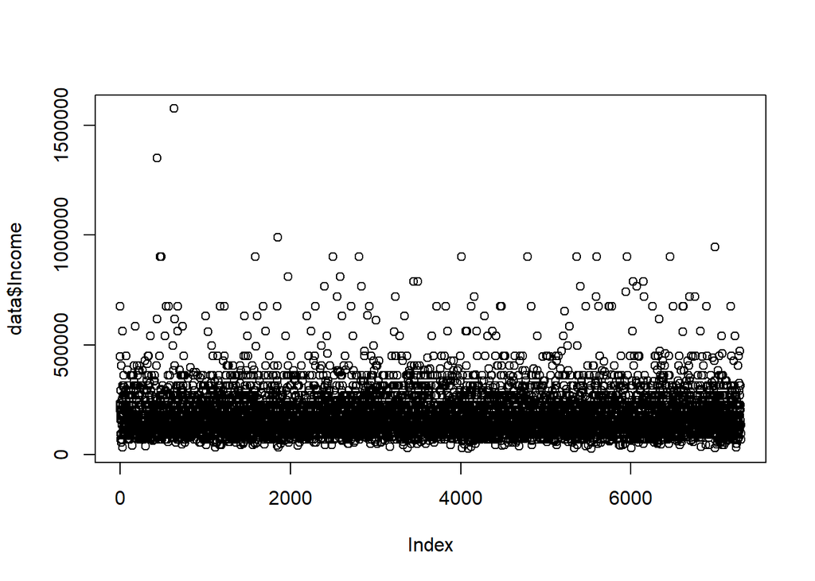

```r
plot(data$Income)
```

### Histogramas

Es un tipo de gráfica de barras que muestra conteos o frecuencias relativas de valores que caen en diferentes intervalos.

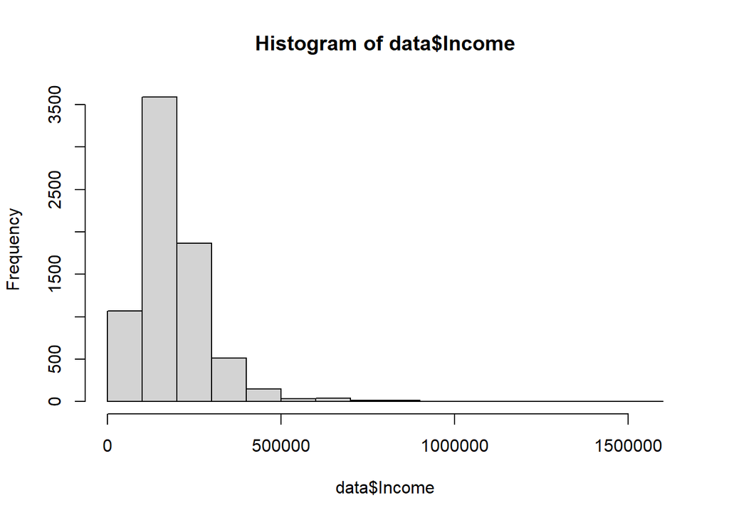

```r
# Usando las gráficas por defecto de R
hist(data$Income)
```

Podemos usar *ggplot()*, un método integrado en *tidyverse* para hacer gráficas más profesionales. Estos códigos no hay que aprendérselos, se pueden crear y personalizar con IA o con herramientas auxiliares como *esquisse* que veremos más adelante.

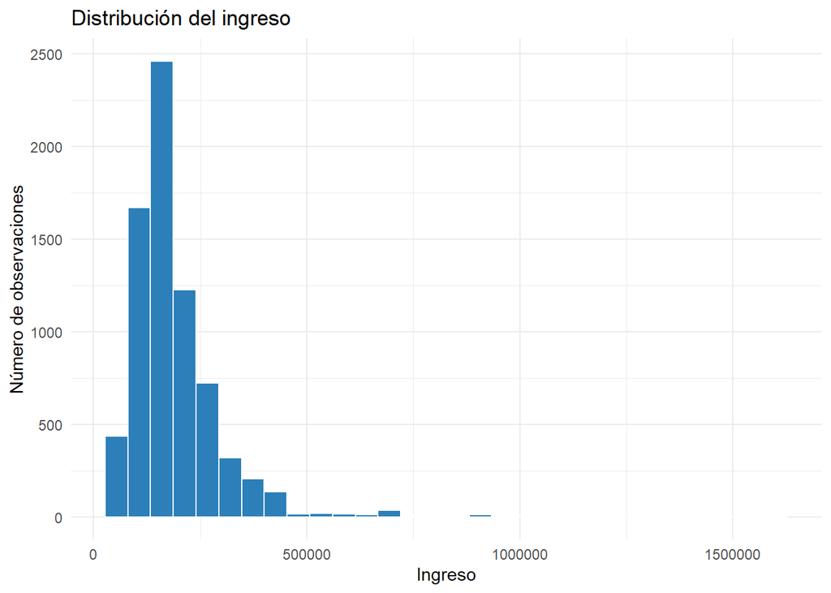

```r
# Histograma de Income usando ggplot
ggplot(data, aes(x = Income)) +
  geom_histogram(bins = 30, na.rm = TRUE, fill = "#2c7fb8", color = "white") +
  labs(
    title = "Distribución del ingreso",
    x = "Ingreso",
    y = "Número de observaciones"
  ) +
  theme_minimal()
```

### Gráficos de densidad (también llamados gráficas Kernel o histogramas suavizados)

Muestra las frecuencias relativas locales de los puntos a lo largo del eje X. En otras palabras, en los intervalos donde hay más puntos/observaciones la gráfica crece indicando mayor “densidad”.

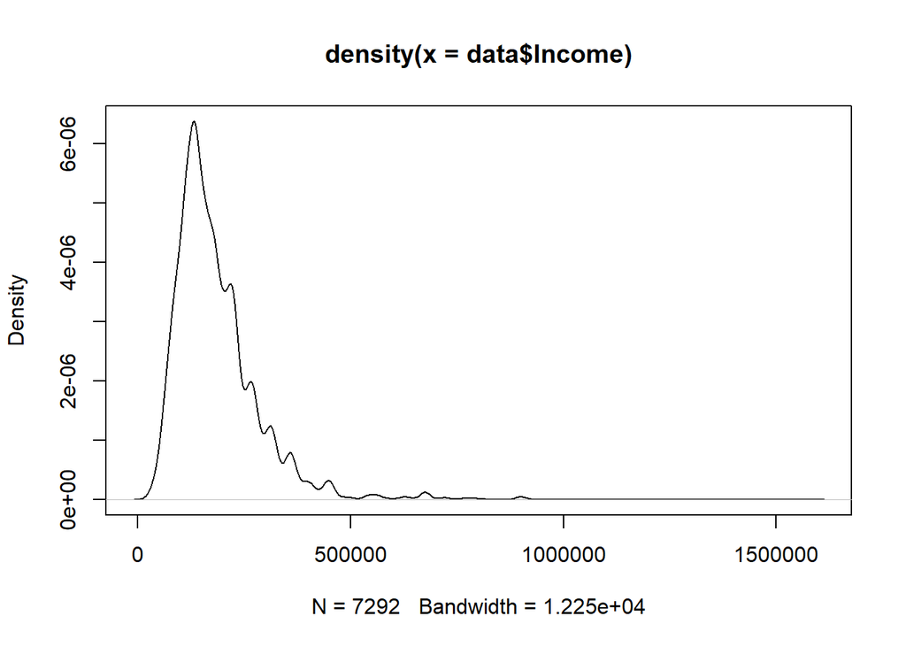

```r
plot(density(data$Income))
```

> Los gráficos de densidad son muy útiles para determinar la función de distribución de probabilidad de una variable cuantitativa.

### Gráfico Q-Q

Se usa para revisar si los datos siguen una distribución aproximadamente normal.

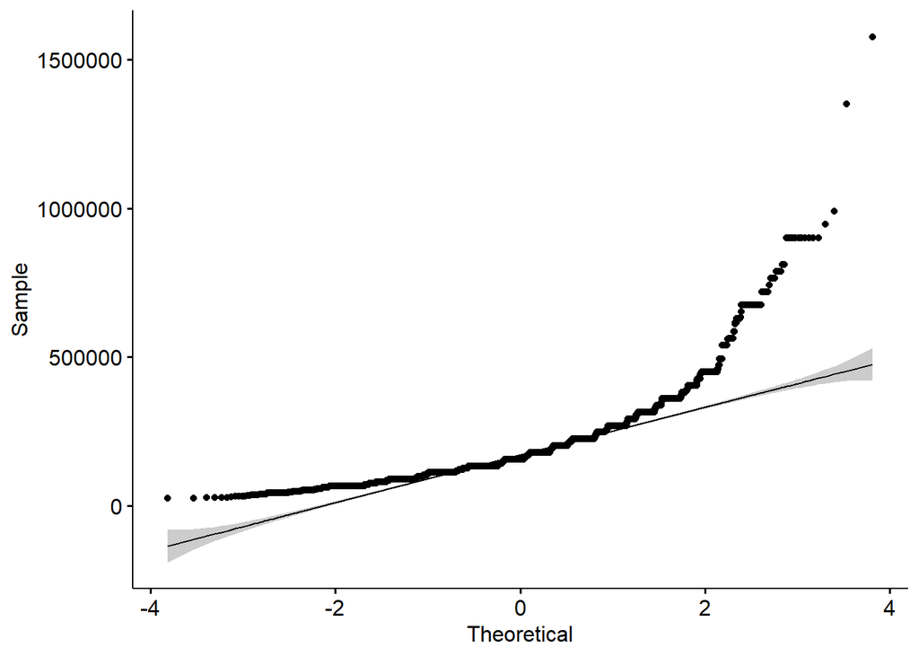

```r
ggqqplot(data, x = "Income")
```

### Función de distribución empírica acumulada

Muestra la frecuencia relativa acumulada para los valores de la muestra.

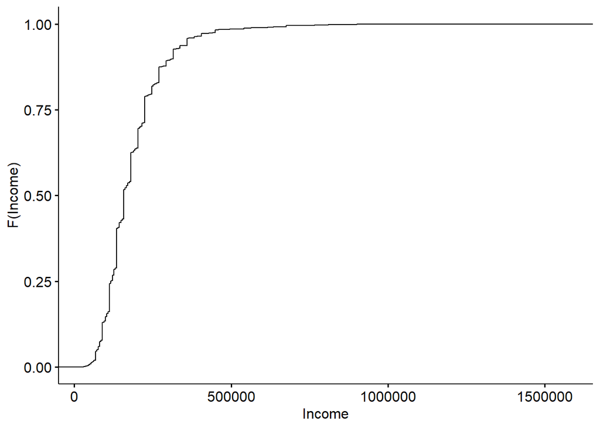

```r
ggecdf(data, x = "Income")
```

### Boxplot

Muestra la ubicación, dispersión y distribución de una variable mediante la construcción de una figura en forma de caja con un conjunto de líneas (bigotes) que se extienden desde los extremos de la caja. Los bordes del cuadro se dibujan en los percentiles 25 y 75 de los datos, y una línea en el medio del cuadro marca el percentil 50.

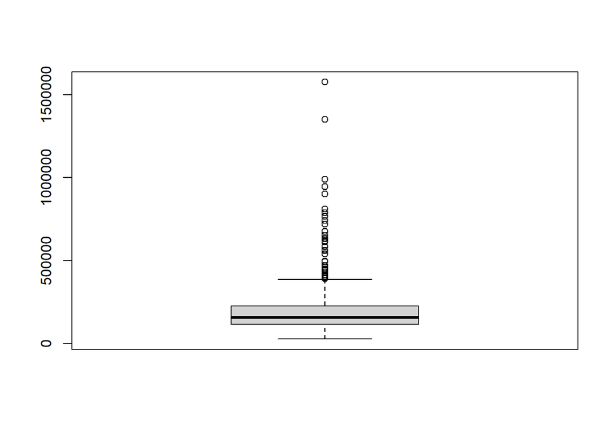

```r
boxplot(data$Income)
```

> **Nota**: las variables cuantitativas representan cantidades y pueden ser discretas o continuas; generalmente se visualizan mediante histogramas y boxplots. Las variables categóricas representan grupos o categorías y suelen resumirse mediante tablas de frecuencias y diagramas de barras.

### Diagrama de barras

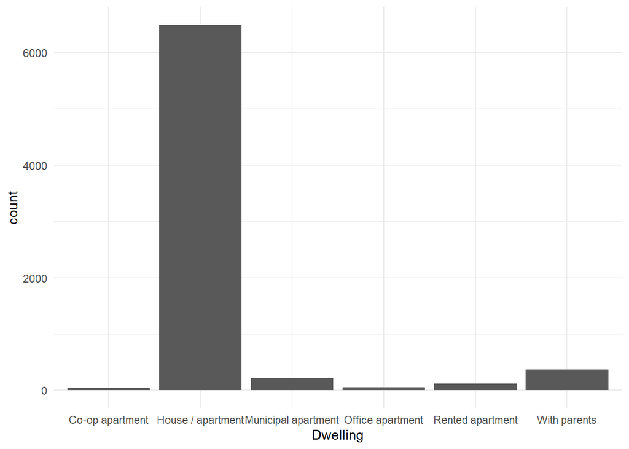

```r
# Sin orden
ggplot(data, aes(x = Dwelling))+
  geom_bar(stat="count")+
  theme_minimal()
```

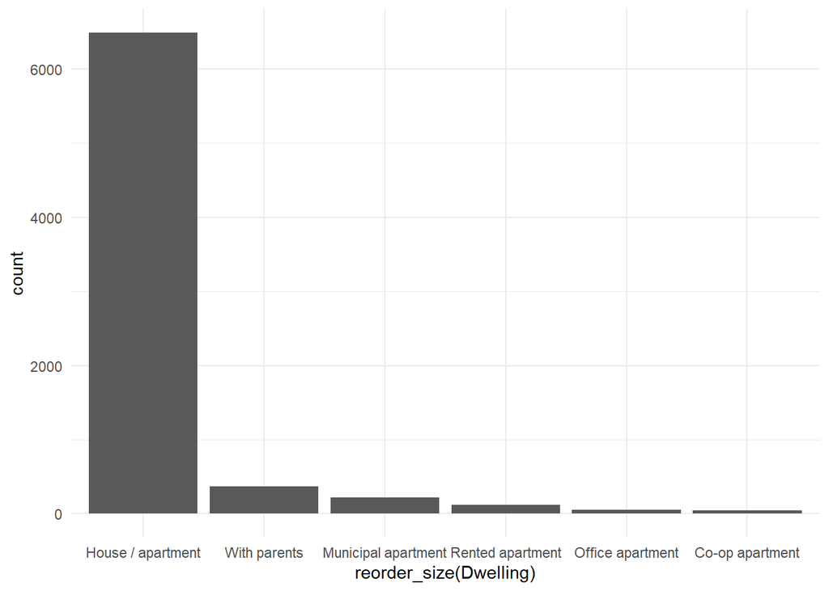

```r
# Ordenado
# Función para reordenar los factores de un vector en orden decreciente
reorder_size <- function(x) {
        factor(x, levels = names(sort(table(x), decreasing = TRUE)))
}
ggplot(data, aes(x = reorder_size(Dwelling)))+
  geom_bar(stat="count")+
  theme_minimal()
```

## Gráficos bivariados y multivariados

### Ejemplo: diagrama de dispersión entre dos variables contínuas

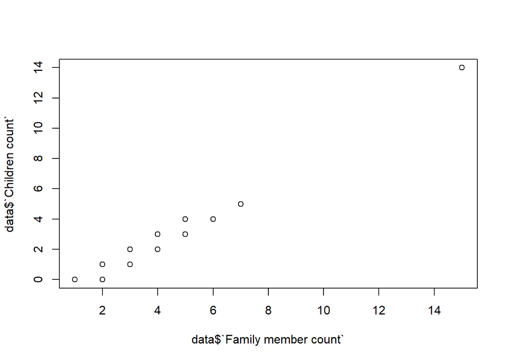

```r
plot(data$`Family member count`, data$`Children count`)
```

### Ejemplo: boxplot por grupos (una variable contínua y una categórica)

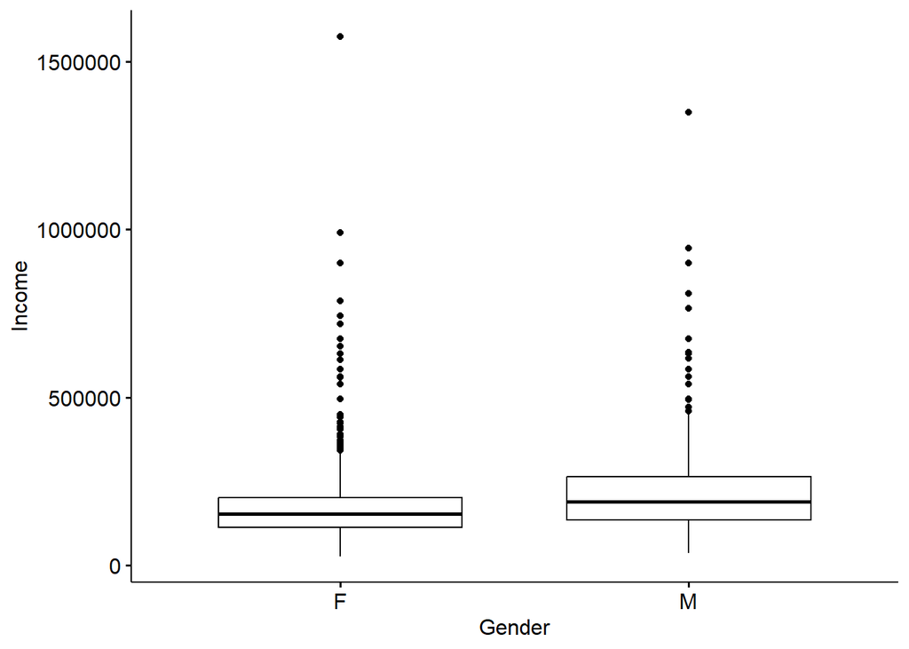

```r
ggboxplot(data, x = "Gender", y = "Income",
          palette = c("#00AFBB", "#E7B800"))
```

### Ejemplo: matríz de correlación gráfica

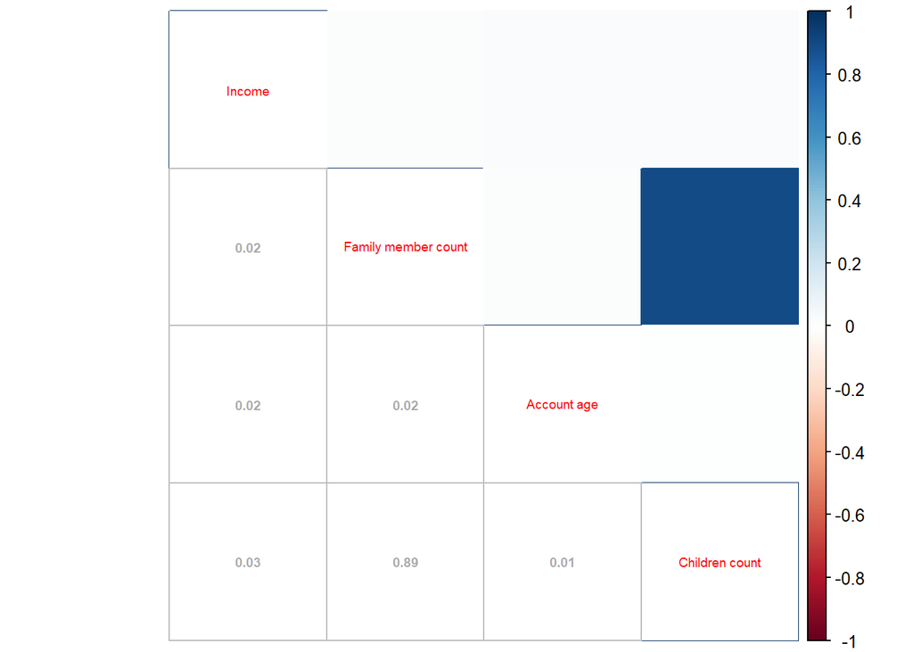

```r
library("corrplot")
variables_seleccionadas <- c("Income","Family member count","Account age","Children count")
data[variables_seleccionadas] -> variables_numericas
variables_numericas %>%
  cor %>%
  corrplot.mixed(lower = "number", upper = "color", lower.col = "#aaaaaa", number.cex = 0.6, tl.cex = 0.6)
```

## Herramienta gráfica útil *esquisse*

`esquisse` es un paquete que se puede instalar y puede ayudar a explorar la *gramática* de las graficas usando `ggplot2`, pero el código generado debe leerse, ejecutarse y documentarse.

```r
## Instalamos la librería
# install.packages("esquisse")

## Cargamos la librería
# library("esquisse")

## Llamamos a la función esquisser especificando con cuales datos queremos trabajar
# esquisser(data = data, viewer = "browser")
```

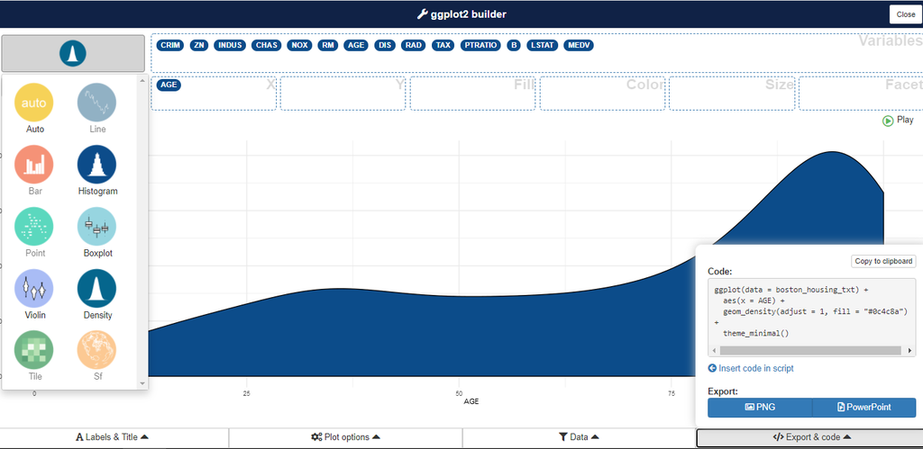

## Gráficos profesionales

- [Galería de gráficas en R](https://www.r-graph-gallery.com/)
- [Top 50 de visualizaciones en R](http://r-statistics.co/Top50-Ggplot2-Visualizations-MasterList-R-Code.html)

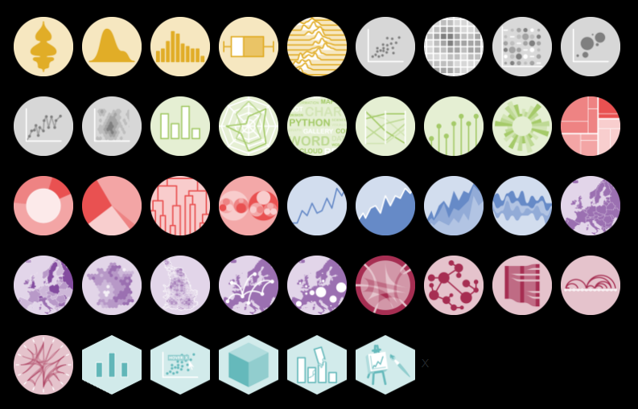

## Práctica aplicada

Elija una base y prepare un EDA que incluya:

1. Un resumen de la estructura y los faltantes.
2. Una gráfica univariada para una variable cuantitativa.
3. Una gráfica univariada para una variable categórica.
4. Una visualización bivariada justificada.
5. Un comentario sobre cada resultado, incluyendo una limitación.

## Lista de verificación

- Cada gráfica responde una pregunta.
- Los ejes, unidades y categorías están identificados.
- Los faltantes y valores extremos se consideran.
- Las asociaciones (correlaciones) no se describen como causalidad.